# Project 1

Van Nguyen

2024-10-11

```r
# https://archive.ics.uci.edu/dataset/1/abalone
cname <- c("Sex","Length","Diameter","Height","Whole weight","Shucked weight","Viscera weight","Shell weight","Ring")
abalone <- read.csv("C:/Users/LapWork/Downloads/abalone/abalone.data",col.names = cname)
```

## The Dataset: Abalone

For the abalone dataset, I want to predict the age (the number of rings) of the abalone using the length, diameter, height, weight and shell weight since to find the age you have to cut open the shell and count the numbers rings under a microscope. This is for people who weighed their abalone before eating it and still had the shell afterward and was curious about its age.

## Summarizing the Data

```r
aba <- abalone[,c(2:5,8:9)]
summary(aba)
```

```
##      Length         Diameter          Height        Whole.weight
##  Min.   :0.075   Min.   :0.0550   Min.   :0.0000   Min.   :0.0020
##  1st Qu.:0.450   1st Qu.:0.3500   1st Qu.:0.1150   1st Qu.:0.4415
##  Median :0.545   Median :0.4250   Median :0.1400   Median :0.7997
##  Mean   :0.524   Mean   :0.4079   Mean   :0.1395   Mean   :0.8288
##  3rd Qu.:0.615   3rd Qu.:0.4800   3rd Qu.:0.1650   3rd Qu.:1.1533
##  Max.   :0.815   Max.   :0.6500   Max.   :1.1300   Max.   :2.8255
##   Shell.weight         Ring
##  Min.   :0.0015   Min.   : 1.000
##  1st Qu.:0.1300   1st Qu.: 8.000
##  Median :0.2340   Median : 9.000
##  Mean   :0.2389   Mean   : 9.932
##  3rd Qu.:0.3290   3rd Qu.:11.000
##  Max.   :1.0050   Max.   :29.000
```

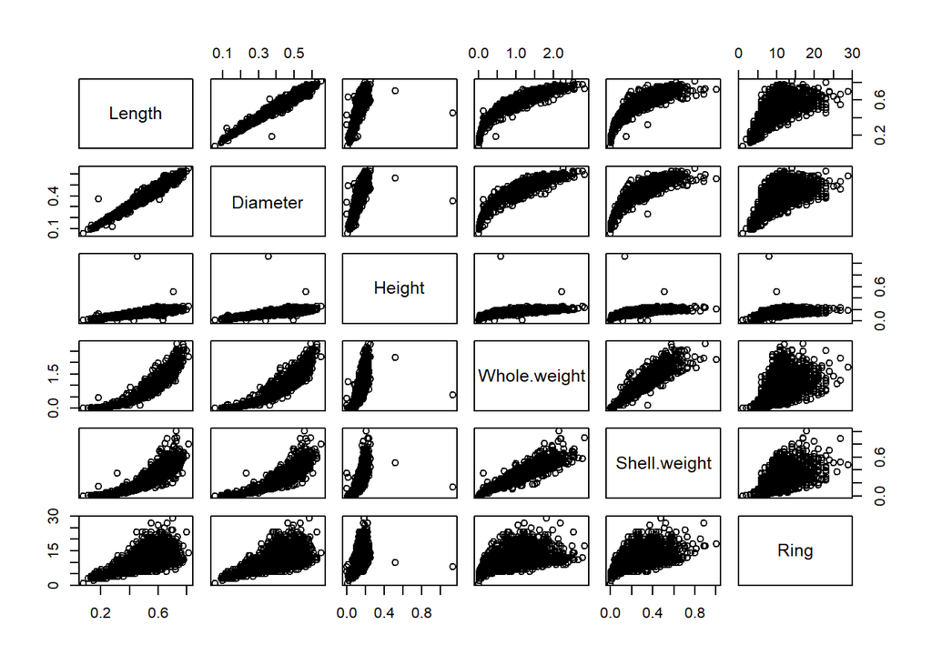

```r
plot(aba)
```

While the relationship between some predictor looks linear, in regards to weight, it looks exponential. The predictors looks to be all correlated to some degree. The general trends looks to be the bigger and heavier the abalone is, the more rings it have.

## Regression Models

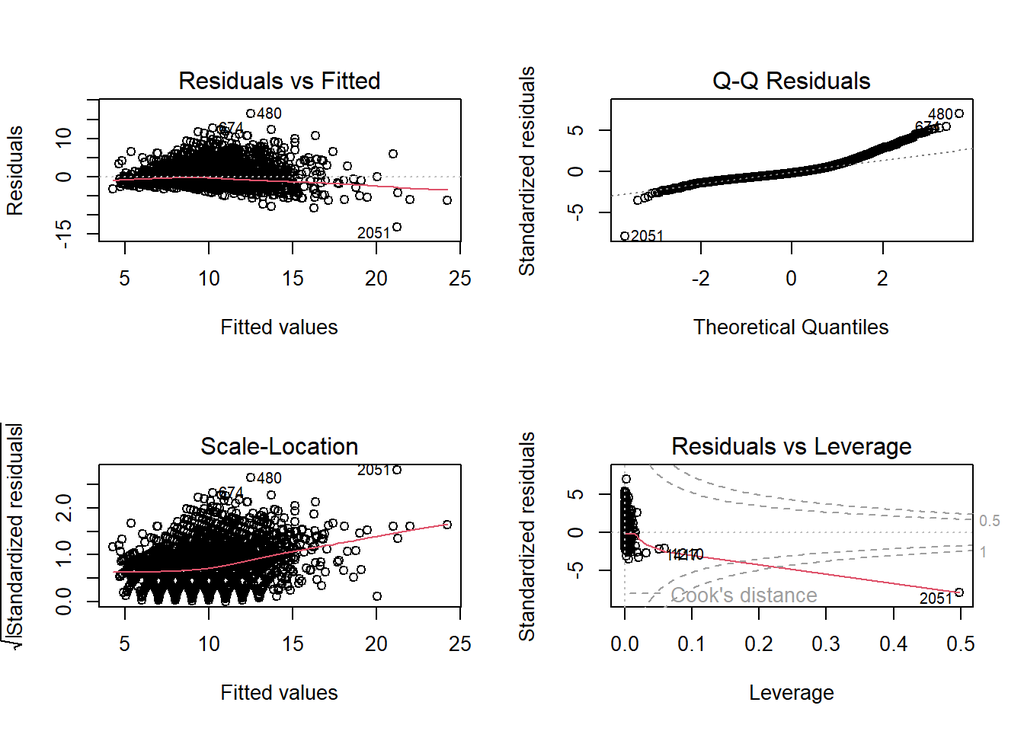

```r
mod1 <- lm(Ring ~ ., data=aba)
par(mfrow=c(2,2))
plot(mod1)
```

There is fanning in the residual vs fitted graph and the q-q residual curves up toward the end. The scale-location graph has a bouncing ball pattern and in the residual vs leverage there is one very big outlier.

```r
summary(mod1)
```

```
##
## Call:
## lm(formula = Ring ~ ., data = aba)
##
## Residuals:
##      Min       1Q   Median       3Q      Max
## -13.2140  -1.4464  -0.4976   0.8820  16.5050
##
## Coefficients:
##              Estimate Std. Error t value Pr(>|t|)
## (Intercept)    3.6973     0.2845  12.997  < 2e-16 ***
## Length        -5.2437     1.9393  -2.704  0.00688 **
## Diameter      14.2812     2.3899   5.976 2.49e-09 ***
## Height        13.1622     1.6509   7.973 1.99e-15 ***
## Whole.weight  -5.9579     0.2966 -20.088  < 2e-16 ***
## Shell.weight  26.2054     0.9259  28.302  < 2e-16 ***
## ---
## Signif. codes:  0 '***' 0.001 '**' 0.01 '*' 0.05 '.' 0.1 ' ' 1
##
## Residual standard error: 2.371 on 4170 degrees of freedom
## Multiple R-squared:  0.4598, Adjusted R-squared:  0.4592
## F-statistic:   710 on 5 and 4170 DF,  p-value: < 2.2e-16
```

With a p-value of < 2.2e-16 it means the overall model is significant. Additionally the p-values for the variable are all less than 0.05 so they are also significant.So far model seems to be reliable to predict the age of the abalone. The $R^2$ value of 0.4598 is low but I’ll reserve my judgement on it until after I apply a log transformation.

```r
# Removing a outlier
aba1 <- aba[-c(2051),]

# applying log transformtation to Ring
mod2 <- lm(log(Ring) ~ ., data=aba1)
summary(mod2)
```

```
##
## Call:
## lm(formula = log(Ring) ~ ., data = aba1)
##
## Residuals:
##      Min       1Q   Median       3Q      Max
## -1.38062 -0.14286 -0.02795  0.11473  0.87441
##
## Coefficients:
##              Estimate Std. Error t value Pr(>|t|)
## (Intercept)   1.26277    0.02611  48.355  < 2e-16 ***
## Length        0.04313    0.17632   0.245    0.807
## Diameter      1.53760    0.21837   7.041 2.22e-12 ***
## Height        2.84174    0.21158  13.431  < 2e-16 ***
## Whole.weight -0.63052    0.02695 -23.392  < 2e-16 ***
## Shell.weight  1.92502    0.08540  22.542  < 2e-16 ***
## ---
## Signif. codes:  0 '***' 0.001 '**' 0.01 '*' 0.05 '.' 0.1 ' ' 1
##
## Residual standard error: 0.2154 on 4169 degrees of freedom
## Multiple R-squared:  0.5461, Adjusted R-squared:  0.5456
## F-statistic:  1003 on 5 and 4169 DF,  p-value: < 2.2e-16
```

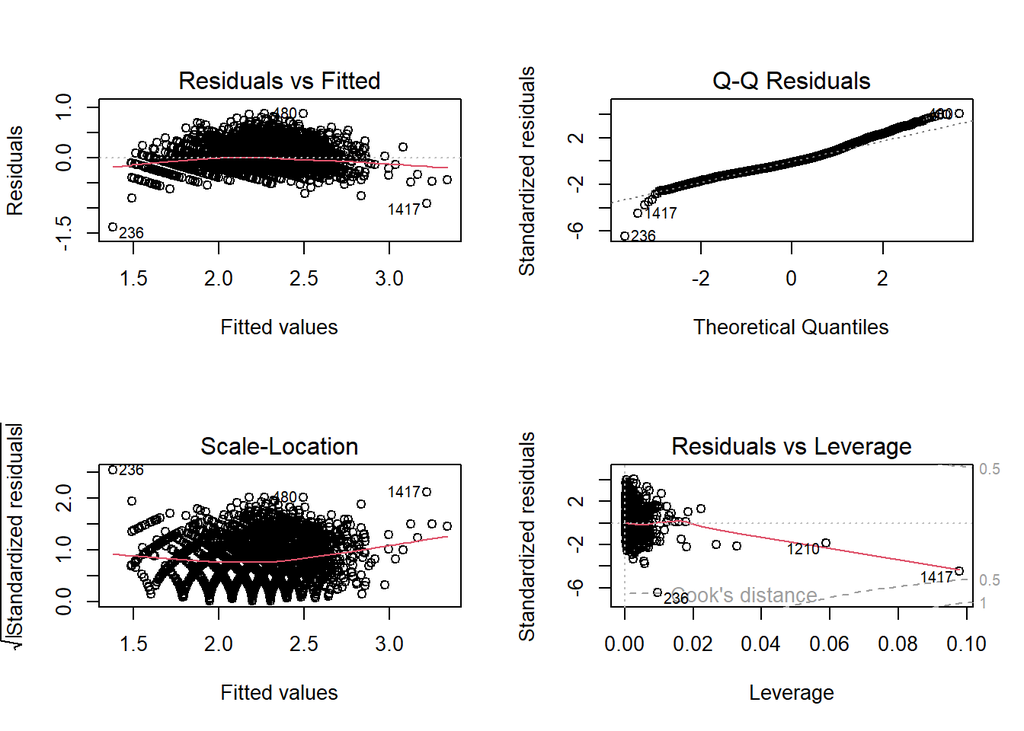

```r
par(mfrow=c(2,2))
plot(mod2)
```

After applying the log transformation the graphs looks a lot better. The fanning in residual vs fitted is gone and the upward curve in q-q residuals is more linear. However there are some potential issues. In scale-location the pattern from before remains the same warranting a check on the variance. I’m not sure how well it will show but in the residual vs fitted, it looks to be a series of repeated linear lines clumped next to each other. The $R^2$ value of 0.5461 is much better than before but the model does not account for over 40% of the variability.

```r
vif(mod2)
```

```
##       Length     Diameter       Height Whole.weight Shell.weight
##    40.357001    42.271084     6.101768    15.726346    12.717855
```

```r
cor(aba1)
```

```
##                 Length  Diameter    Height Whole.weight Shell.weight      Ring
## Length       1.0000000 0.9868124 0.8929935    0.9252512    0.8976899 0.5570861
## Diameter     0.9868124 1.0000000 0.8993481    0.9254478    0.9053244 0.5749732
## Height       0.8929935 0.8993481 1.0000000    0.8834309    0.8831387 0.6035376
## Whole.weight 0.9252512 0.9254478 0.8834309    1.0000000    0.9553560 0.5407872
## Shell.weight 0.8976899 0.9053244 0.8831387    0.9553560    1.0000000 0.6279920
## Ring         0.5570861 0.5749732 0.6035376    0.5407872    0.6279920 1.0000000
```

All the predictor variable has a high variance inflation factor. Also, the chosen predictors suffers from high correlation with each other. Lets try accounting for some of them.

```r
mod3 <- lm(log(Ring) ~  Height + Diameter + Length +Length*Diameter +  Whole.weight + Shell.weight + Shell.weight*Whole.weight, data=aba1)
summary(mod3)
```

```
##
## Call:
## lm(formula = log(Ring) ~ Height + Diameter + Length + Length *
##     Diameter + Whole.weight + Shell.weight + Shell.weight * Whole.weight,
##     data = aba1)
##
## Residuals:
##      Min       1Q   Median       3Q      Max
## -1.06315 -0.13813 -0.02753  0.11392  0.96984
##
## Coefficients:
##                           Estimate Std. Error t value Pr(>|t|)
## (Intercept)                0.76411    0.04983  15.334  < 2e-16 ***
## Height                     1.53712    0.21365   7.195 7.39e-13 ***
## Diameter                   3.76798    0.26699  14.113  < 2e-16 ***
## Length                     1.30330    0.19745   6.601 4.60e-11 ***
## Whole.weight              -0.14522    0.04102  -3.540 0.000404 ***
## Shell.weight               2.44263    0.11736  20.813  < 2e-16 ***
## Diameter:Length           -5.98698    0.34963 -17.124  < 2e-16 ***
## Whole.weight:Shell.weight -0.24890    0.06102  -4.079 4.60e-05 ***
## ---
## Signif. codes:  0 '***' 0.001 '**' 0.01 '*' 0.05 '.' 0.1 ' ' 1
##
## Residual standard error: 0.2061 on 4167 degrees of freedom
## Multiple R-squared:  0.5845, Adjusted R-squared:  0.5838
## F-statistic: 837.2 on 7 and 4167 DF,  p-value: < 2.2e-16
```

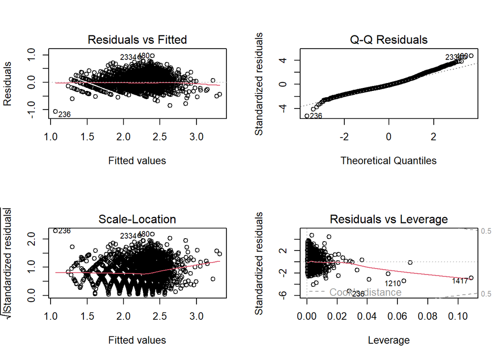

```r
par(mfrow=c(2,2))
plot(mod3)
```

The previous issues still remain. The series of linear lines in residual vs fitted is more viable than before. The $R^2$ value is higher than before, 0.5845, and the model and predictors still remain significant in predicting the number of rings (age) of the abalone. Since all the predictors used here have high correlation with each other I assume adding more independent predictor like Gender and accounting for more of the correlation might help.

## Conclusion

Looking at the final model, while higher height, length, diameter and shell weight increases the number of rings, the heavier the entire abalone is, the younger the abalone. So it is possible to predict the age of an abalone given you weighed it before you ate it. But seeing the whole weight coefficient makes me think with more predictors and accounting for more correlation, it might not be significant to the model. More work is need on the model as it has a $R^2$ of 0.5845 which mean the model only accounts for a bit over half of the variability. I did try a model where I multiple all the predictor together and obtain a significant model, < 2.2e-16, and a $R^2$ of 0.6092. I did not include it as the output was long and most of the predictor were not significant, not less than 0.05. If I were to continue working on the model with these predictor, I might look through this model, see what correlation were signicant and should account for.